# Do not over-think about ‘outliers’, use a student-t distribution instead

Author

Affiliation

Daniel Manrique-Castano

Univerisity Laval (Laboratory of neurovascular interactions)

Published

Friday, March 29, 2024

Keywords

Student’s-t distribution, Bayesian modeling, brms

For many researchers, outliers are rogue waves that can dramatically alter the course of the analysis or “confound” some expected effects. I prefer to use the term “extreme observations” and leave the term outlier for observations that are not truly part of the population being studied. For example, in my field (brain ischemia research), an outlier is an animal that does not have ischemia (when it should have), while extreme observations are animals with small or large ischemias that are very different from the others.

Traditional (frequentist) statistical models are built on the strong foundation of Gaussian distributions. This has a significant limitation: an inherent assumption that all data points will cluster around a central mean in a predictable pattern (based on the central limit theorem). This may be true in Plato’s world of ideas, but we scientists in the biomedical field are well aware that it is extremely difficult to rely on this assumption given the limited sampling (number of animals) we have available to make observations.

Gaussian distributions are very sensitive to extreme observations, and their use leads scientists to believe that eliminating extreme observations is the best way to get “clearer” or “cleaner” results (whatever that means). As I once commented in an article as reviewer 2, “The problem is not the extreme observations that may”hide” your effects, but the fact that you are using a statistical model that (I believe) is inappropriate for your purposes”. It should be noted that no statistical model is the “right” or “appropriate” one, but we can estimate that, given the data, there are certain statistical models that are more likely to generate the observed data (generative models) than others.

Fortunately, nothing forces us to be bound by the assumptions of the Gaussian models, right? We have other options, such as the **Student’s t-distribution** (*1*). I see it as a more adaptable vessel to navigate the turbulent seas of real-world biomedical data. The Student’s t-distribution provides a robust alternative to acknowledge that our data may be populated by extreme observations that are normal biological responses that we can expect in any context. There may be patients or animals that don’t respond or overreact to a treatment, and it is valuable that our modeling approach recognizes these responses as part of the spectrum. Therefore, this tutorial explores the modeling strategies using Student’s t-distributions through the lens of the **`brms`** package for R (*2*)—a powerful ally for Bayesian modeling.

# 1 What’s behind a student’s t-distribution?

A [Student’s t-distribution](https://mathworld.wolfram.com/Studentst-Distribution.html) is nothing more than a Gaussian distribution with heavier tails. In other words, we can say that the Gaussian distribution is a special case of the Student’s t-distribution. The Gaussian distribution is defined by the mean (μ) and the standard deviation (σ). The Student t distribution, on the other hand, adds an additional parameter, the degrees of freedom (df), which controls the “thickness” of the distribution. This parameter assigns greater probability to events further from the mean. This feature is particularly useful for small sample sizes, such as in biomedicine, where the assumption of normality is questionable. Note that as the degrees of freedom increase, the Student t-distribution approaches the Gaussian distribution. We can observe this in the following:

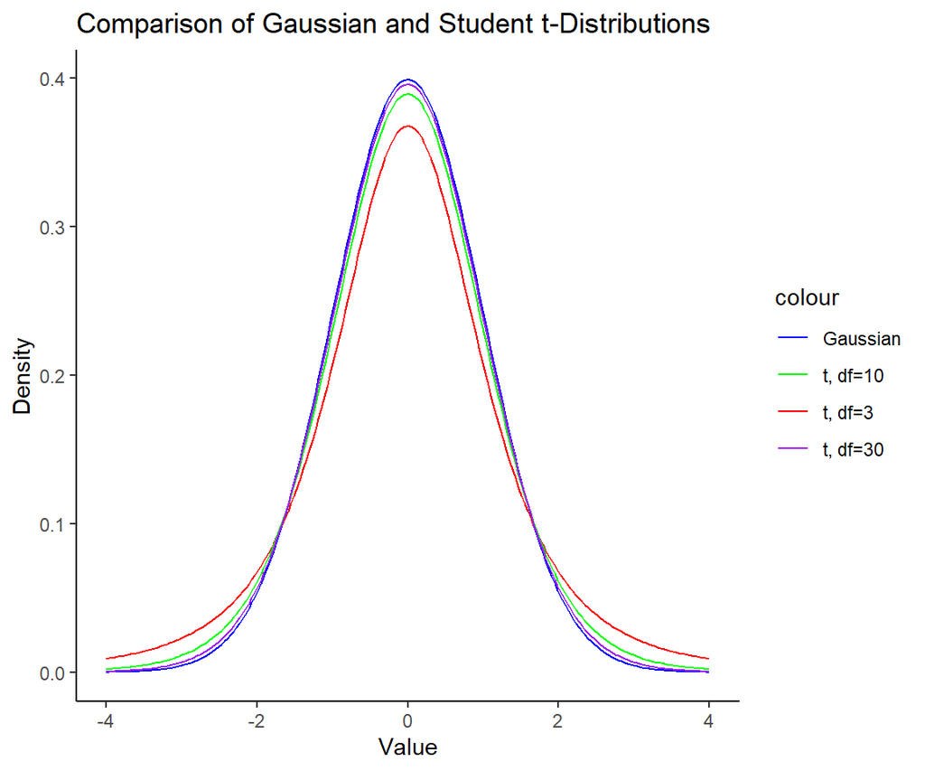

Figure 1: Comparison of Gaussian and Student t-Distributions with different degrees of freedom.

```r
# Load necessary libraries
library(ggplot2)

# Set seed for reproducibility
set.seed(123)

# Define the distributions
x <- seq(-4, 4, length.out = 200)
y_gaussian <- dnorm(x)
y_t3 <- dt(x, df = 3)
y_t10 <- dt(x, df = 10)
y_t30 <- dt(x, df = 30)

# Create a data frame for plotting
df <- data.frame(x, y_gaussian, y_t3, y_t10, y_t30)

# Plot the distributions
ggplot(df, aes(x)) +
  geom_line(aes(y = y_gaussian, color = "Gaussian")) +
  geom_line(aes(y = y_t3, color = "t, df=3")) +
  geom_line(aes(y = y_t10, color = "t, df=10")) +
  geom_line(aes(y = y_t30, color = "t, df=30")) +
  labs(title = "Comparison of Gaussian and Student t-Distributions",
       x = "Value",
       y = "Density") +
  scale_color_manual(values = c("Gaussian" = "blue", "t, df=3" = "red", "t, df=10" = "green", "t, df=30" = "purple")) +
  theme_classic()
```

Note in Figure 1 that the hill around the mean gets smaller as the degrees of freedom decrease as a result of the probability mass going to the tails, which are thicker. This property is what gives the Student’s t-distribution a reduced sensitivity to outliers. For more details in this matter you can check [this](https://online.stat.psu.edu/stat414/lesson/26/26.4) blog.

## 1.1 Load packages and themes

We load the required libraries and create a visual theme for our plots.

```r
library(ggplot2)
library(brms)
library(ggdist)
library(easystats)
library(dplyr)
library(tibble)
library(ghibli)

Plot_theme <- theme_classic() +
  theme(
      plot.title = element_text(size=18, hjust = 0.5, face="bold"),
      plot.subtitle = element_text(size = 10, color = "black"),
      plot.caption = element_text(size = 12, color = "black"),
      axis.line = element_line(colour = "black", size = 1.5, linetype = "solid"),
      axis.ticks.length=unit(7,"pt"),

      axis.title.x = element_text(colour = "black", size = 16),
      axis.text.x = element_text(colour = "black", size = 16, angle = 0, hjust = 0.5),
      axis.ticks.x = element_line(colour = "black", size = 1),

      axis.title.y = element_text(colour = "black", size = 16),
      axis.text.y = element_text(colour = "black", size = 16),
      axis.ticks.y = element_line(colour = "black", size = 1),

      legend.position="right",
      legend.direction="vertical",
      legend.title = element_text(colour="black", face="bold", size=12),
      legend.text = element_text(colour="black", size=10),

      plot.margin = margin(t = 10,  # Top margin
                             r = 2,  # Right margin
                             b = 10,  # Bottom margin
                             l = 10) # Left margin
      )
```

# 2 Exploratory data visualization

So, let’s skip data simulations and get serious. We’ll work with real data I have acquired from mice performing in the rotarod test.

## 2.1 Load the dataset

First, we load the dataset into our environment and set the corresponding factor levels.

```r
data <- read.csv("Data/Rotarod.csv")
data$Day <- factor(data$Day, levels = c("1", "2"))
data$Genotype <- factor(data$Genotype, levels = c("WT", "KO"))
head(data)
```

```
  Animal Genotype Day Trial1 Trial2 Trial3
1   KO10       KO   1     57     69     59
2   KO11       KO   1     94     50     67
3   KO12       KO   1     45     36     36
4   KO13       KO   1     53     47     59
5   KO14       KO   1     36     49     36
6   KO15       KO   1     35     31     41
```

The dataset contains IDs for the animals, a groping variable (Genotype), an indicator for two different days on which the test was performed (day), and different trials for the same day. For this article, we model only one of the trials (Trial3). We will save the other trials for a future article on modeling variation.

As the data handling implies, our modeling strategy will be based on Genotype and Day as categorical predictors of the distribution of `Trial3`. In biomedical science, categorical predictors, or grouping factors, are more common than continuous predictors. Scientists in this field like to divide their samples into groups or conditions and apply different treatments.

## 2.2 Plot the data

Let’s have an initial view of the data using **Raincloud plots** as show by @amorimfranchi in this great blog post.

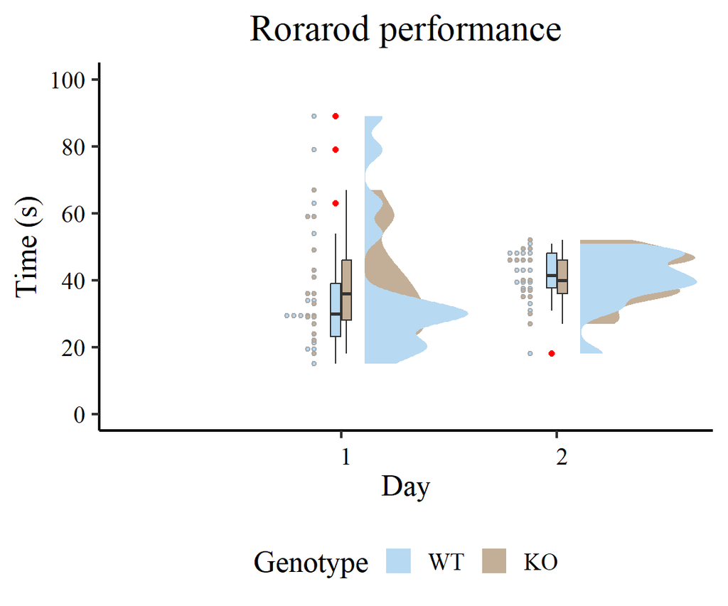

Figure 2: Exploratory data visualization.

```r
edv <- ggplot(data, aes(x = Day, y = Trial3, fill=Genotype)) +
  scale_fill_ghibli_d("SpiritedMedium", direction = -1) +
  geom_boxplot(width = 0.1,
               outlier.color = "red") +
  xlab('Day') +
  ylab('Time (s)') +
  ggtitle("Rorarod performance") +
  theme_classic(base_size=18, base_family="serif")+
  theme(text = element_text(size=18),
        axis.text.x = element_text(angle=0, hjust=.1, vjust = 0.5, color = "black"),
        axis.text.y = element_text(color = "black"),
        plot.title = element_text(hjust = 0.5),
        plot.subtitle = element_text(hjust = 0.5),
        legend.position="bottom")+
  scale_y_continuous(breaks = seq(0, 100, by=20),
                     limits=c(0,100)) +
# Line below adds dot plots from {ggdist} package
  stat_dots(side = "left",
            justification = 1.12,
            binwidth = 1.9) +
# Line below adds half-violin from {ggdist} package
  stat_halfeye(adjust = .5,
               width = .6,
               justification = -.2,
               .width = 0,
               point_colour = NA)
edv
```

Figure 2 looks different from the original by @amorimfranchi because we are plotting two factors instead of one. However, the nature of the plot is the same. Pay attention to the red dots, these are the ones that can be considered as extreme observations that tilt the measures of central tendency (especially the mean) towards one direction. We also observe that the variances are different, so modeling also the sigma can give better estimates. Our task now is to model the output using the `brms` package.

# 3 Fitting stattistical models with brms

Here we fit our model with `Day` and `Genotype` as interacting categorical predictors for the distribution of `Trial 3`. Let’s first fit a typical Gaussian model, which is analogous to an ordinary least squares (OLS) model from the frequentist framework, since we are using the default flat `brms' [priors](https://paul-buerkner.github.io/brms/reference/set_prior.html). Priors are beyond the scope of this article, but I promise we'll cover them in a future blog. Once we have results from the Gaussian model, we can compare them to the large results from the Student's t model. We then add`sigma` to the equation to account for the difference in the variance of the data.

## 3.1 Fitting a “typical” (frequentists) model in Gaussian land

Our Gaussian model is built under the typical (and often incorrect) assumption of homoscedasticity (*3*). In other words, we assume that all groups have the same (or very similar) variance. I do not recall seeing this as a researcher.

```r
Gaussian_Fit1 <- brm(Trial3 ~ Day * Genotype,
           data = data,
           family = gaussian(),
           # seed for reproducibility purposes
           seed = 8807,
           control = list(adapt_delta = 0.99),
           # this is to save the model in my laptop
           file    = "Models/20240222_OutliersStudent-t/Gaussian_Fit1.rds",
           file_refit = "never")

# Add loo for model comparison
Gaussian_Fit1 <-
  add_criterion(Gaussian_Fit1, c("loo", "waic", "bayes_R2"))
```

### 3.1.1 Model diagnostics

Before proceeding, it’s a good idea to do some simple model diagnostics to compare the actual observations with the predictions made by our model. We can do this in several ways, but the most common is to plot full densities. We can achieve this using the `pp_check` function from `brms`.

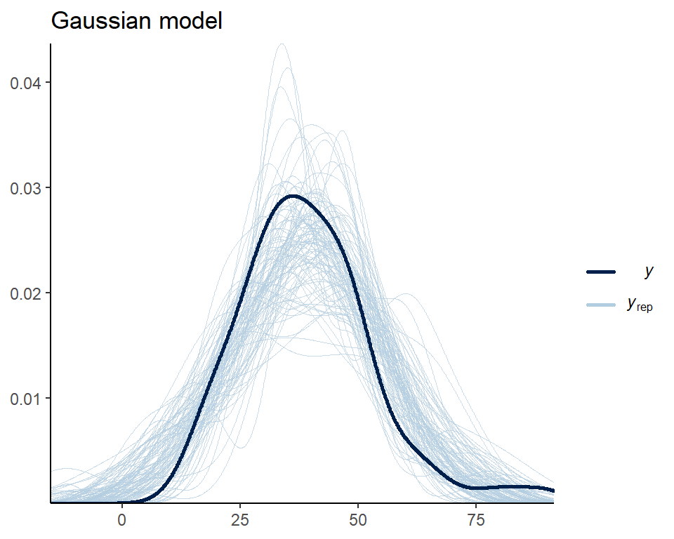

Figure 3: Diagnostics for the Gaussian model

```r
set.seed(8807)

pp_check(Gaussian_Fit1, ndraws = 100) +
  labs(title = "Gaussian model") +
  theme_classic()
```

Figure 3 suggests that our observations (dark blue) are not meaninfully different from the model predictions. Below, I leave you with additional code to check other `pp_check` alternatives with their respective graphs.

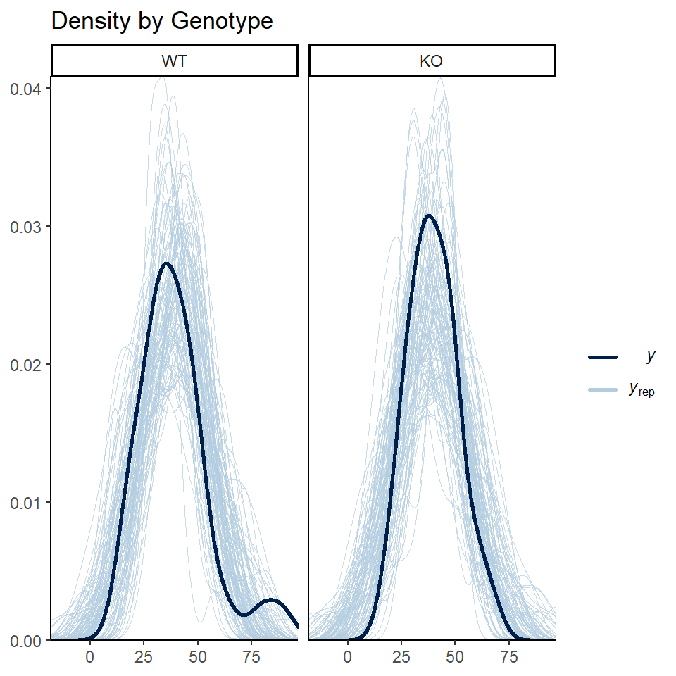

Figure 4

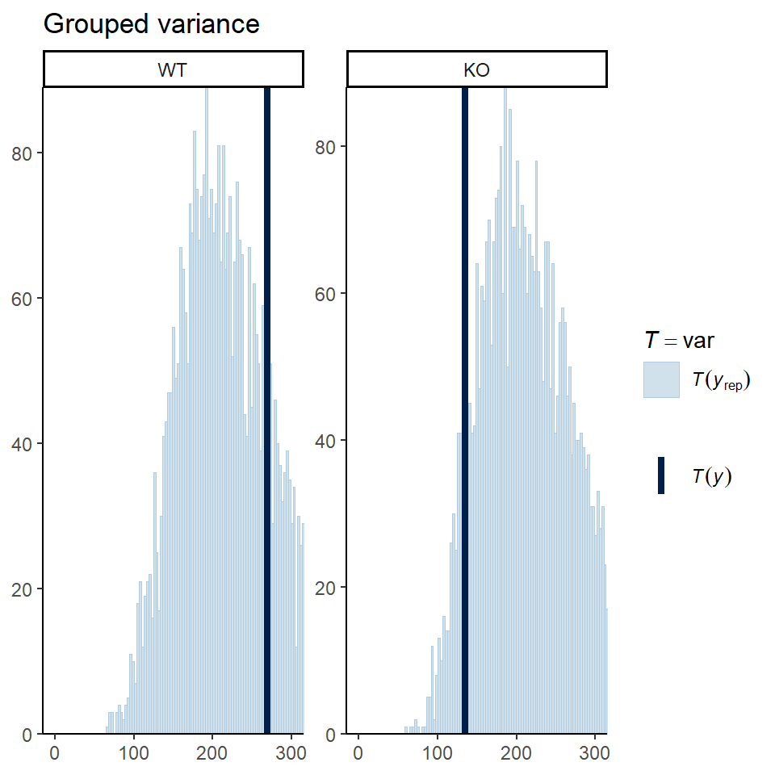

Figure 5

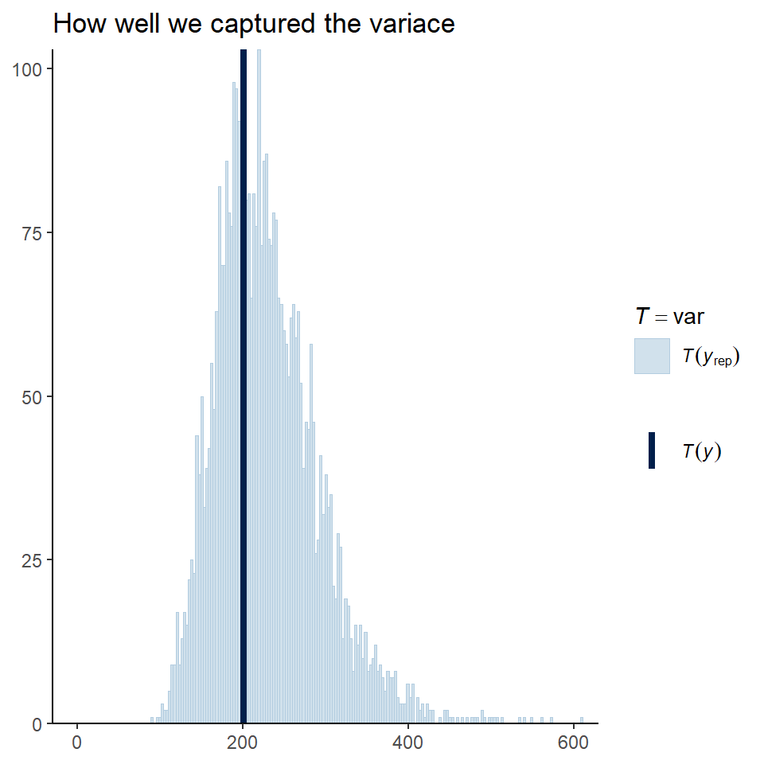

Figure 6

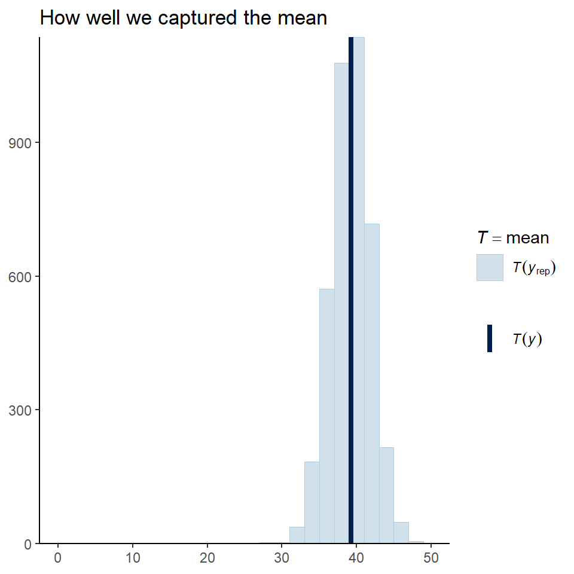

Figure 7

```r
set.seed(88071)


pp_check(Gaussian_Fit1, group = "Genotype", type = "dens_overlay_grouped", ndraws = 100) +
  labs(title = "Density by Genotype") +
    theme_classic()

pp_check(Gaussian_Fit1, type = "stat_grouped", group = "Genotype", stat = "var", binwidth = 3) +
  coord_cartesian(xlim = c(0, 300)) +
  ggtitle("Grouped variance") +
  theme_classic()

pp_check(Gaussian_Fit1, type = "stat", stat = "var", binwidth = 3) +
  coord_cartesian(xlim = c(0, 600)) +
  ggtitle("How well we captured the variace") +
  theme_classic()

pp_check(Gaussian_Fit1, type = "stat", stat = "mean", binwidth = 2) +
  coord_cartesian(xlim = c(0, 50)) +
  ggtitle("How well we captured the mean") +
  theme_classic()
```

### 3.1.2 Checking the results for the Gaussian distribution

Now, we use the `describe_posterior` function from the `bayestestR` package (*4*) to see the results:

```r
describe_posterior(Gaussian_Fit1,
                   centrality = "mean",
                   dispersion = TRUE,
                   ci_method = "HDI",
                   test = "rope",
                   )
```

```
Summary of Posterior Distribution

Parameter       |  Mean |   SD |          95% CI |          ROPE | % in ROPE |  Rhat |     ESS
----------------------------------------------------------------------------------------------
(Intercept)     | 37.43 | 3.61 | [ 29.96, 44.33] | [-1.42, 1.42] |        0% | 1.001 | 2082.00
Day2            |  2.90 | 5.09 | [ -7.17, 13.12] | [-1.42, 1.42] |    19.82% | 1.001 | 1727.00
GenotypeKO      |  0.54 | 5.09 | [ -8.93, 11.01] | [-1.42, 1.42] |    23.05% | 1.001 | 1973.00
Day2:GenotypeKO |  0.15 | 7.29 | [-14.70, 14.39] | [-1.42, 1.42] |    16.66% | 1.002 | 1591.00
```

Let’s focus here on the ‘intercept’, which is the value for WT at 1 DPI, and ‘GenotypeKO’, which is the estimated difference for KO animals at the same time point. We see that WT animals spend about 37 seconds in the rotarod, while their KO counterparts spend less than a second (0.54) more. As a researcher in this field, I can say that this difference is meaningless and that genotype has no effect on rotarod performance. Even the effect of day, which is 2.9, seems meaningless to me under this model. We can easily visualize these estimates using the wonderful `conditional_effects` function from brms.

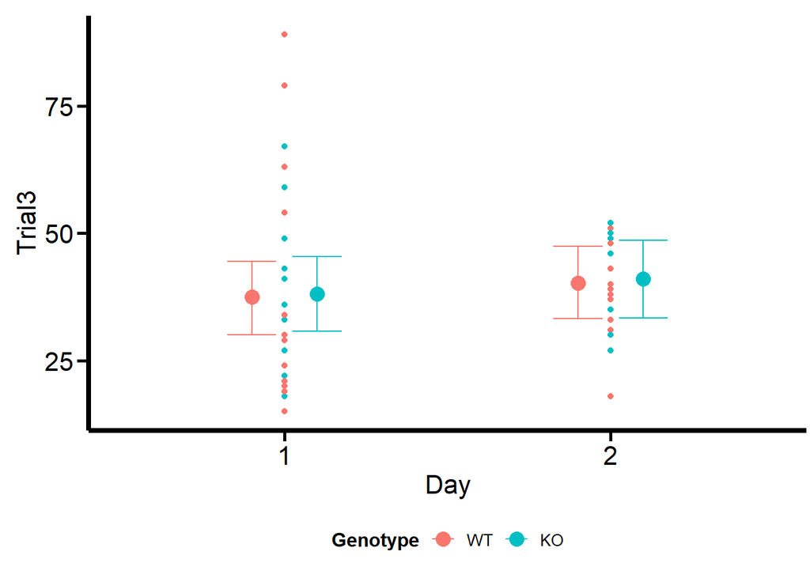

Figure 8: Conditional effects for the Gaussian model

```r
# We create the graph for convex hull
Gaussian_CondEffects <-
  conditional_effects(Gaussian_Fit1)

Gaussian_CondEffects <- plot(Gaussian_CondEffects,
       plot = FALSE)[[3]]

Gaussian_CondEffects +
  geom_point(data=data, aes(x = Day, y = Trial3, color = Genotype), inherit.aes=FALSE) +
  Plot_theme +
  theme(legend.position = "bottom", legend.direction = "horizontal")
```

Now let’s see how much our understanding changes when we model the same data using a student-t distribution.

## 3.2 Fitting our guest: a model with a student-t distribution

```r
Student_Fit <- brm(Trial3 ~ Day * Genotype,
           data = data,
           family = student,
           # seed for reproducibility purposes
           seed = 8807,
           control = list(adapt_delta = 0.99),
           # this is to save the model in my laptop
           file    = "Models/20240222_OutliersStudent-t/Student_Fit.rds",
           file_refit = "never")

# Add loo for model comparison
Student_Fit <-
  add_criterion(Student_Fit, c("loo", "waic", "bayes_R2"))
```

### 3.2.1 Model diagnostics

We plot the model diagnostics as done before

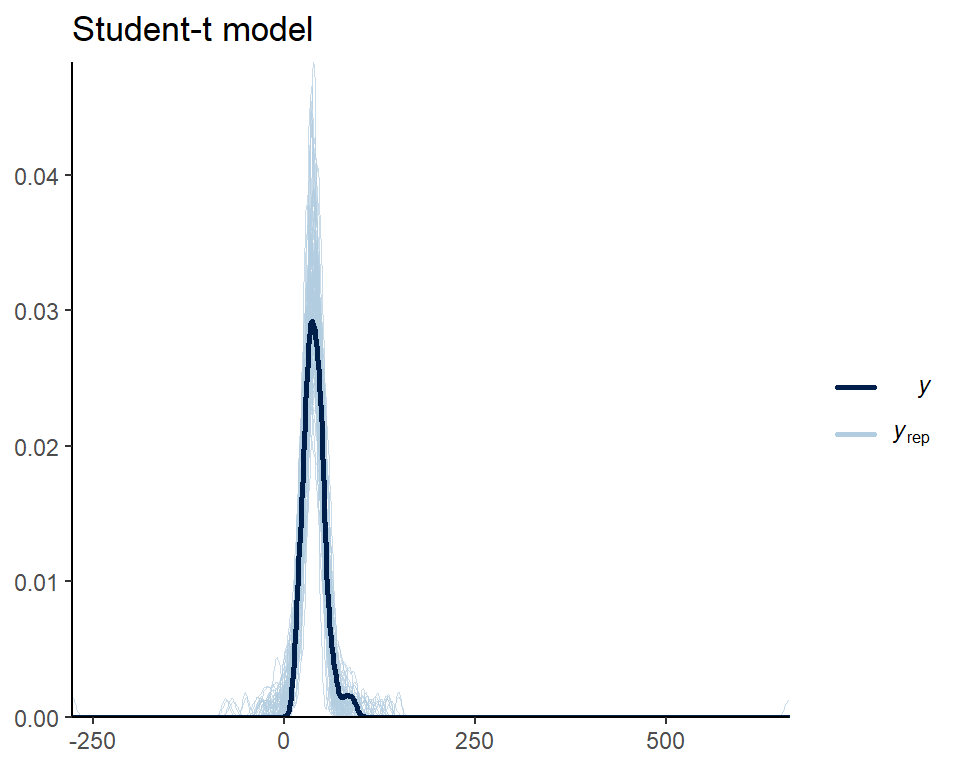

Figure 9: Model diagnostics for student-t distribution

```r
set.seed(8807)

pp_check(Student_Fit, ndraws = 100) +
  labs(title = "Student-t model") +
  theme_classic()
```

Figure 9 we see that the mean shape and the peak of the observations and the predictions match. It’s important to note that our model seems to predict values below 0. This is an important research issue that we will skip for now. However, it does imply the use of informative priors or distribution families that set a lower bound at 0, such as the `log_normal',`hurdle_lognormal’, or `zero_inflated_poisson’, depending on the case. Andrew Heiss (*5*) offers a [great example](https://www.andrewheiss.com/blog/2021/11/08/beta-regression-guide/) on this regard.

### 3.2.2 Chekcing the results for the student-t distribution

Let’s take a look at the posterior distribution:

```r
describe_posterior(Student_Fit,
                   centrality = "mean",
                   dispersion = TRUE,
                   ci_method = "HDI",
                   test = "rope",
                   )
```

```
Summary of Posterior Distribution

Parameter       |  Mean |   SD |          95% CI |          ROPE | % in ROPE |  Rhat |     ESS
----------------------------------------------------------------------------------------------
(Intercept)     | 30.05 | 3.41 | [ 23.45, 36.89] | [-1.42, 1.42] |        0% | 1.002 | 1282.00
Day2            | 11.18 | 4.48 | [  2.14, 19.56] | [-1.42, 1.42] |     0.24% | 1.002 | 1277.00
GenotypeKO      |  5.54 | 4.59 | [ -4.03, 14.08] | [-1.42, 1.42] |    11.97% | 1.005 | 1463.00
Day2:GenotypeKO | -5.44 | 5.94 | [-17.71,  5.37] | [-1.42, 1.42] |    12.92% | 1.004 | 1330.00
```

Let’s see it in graphical terms using `conditional_effects`:

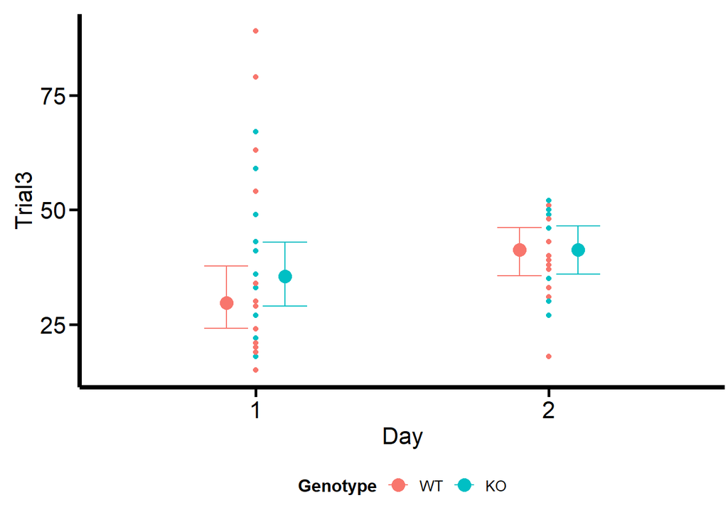

Figure 10: Conditional effects for the Student-t model

```r
Student_CondEffects <-
  conditional_effects(Student_Fit)

Student_CondEffects <- plot(Student_CondEffects,
       plot = FALSE)[[3]]

Student_CondEffects +
  geom_point(data=data, aes(x = Day, y = Trial3, color = Genotype), inherit.aes=FALSE) +
  Plot_theme +
  theme(legend.position = "bottom", legend.direction = "horizontal")
```

Can we get better estimates? For this particular example, I think we can. From the start, it was easy to notice the difference in the variance of the data, especially when we compare the first and second day visuals. We improved our estimates using the student-t distribution, and we can improve them further by developing a model for heteroscedasticity that predicts sigma (the residual variance). In this way, the model does not assume that your residual variance is equal across your grouping variables, but it becomes a response that can be modeled by predictors. This is the little point we left for the end.

## 3.3 Predicting sigma using a student-t distribution

We include sigma as a response variable using the`bf` function from `brms`. In this case, we are going the model this parameter using the same predictors `Day` and `Genotype`.

```r
Student_Mdl2 <- bf (Trial3 ~ Day * Genotype,
                     sigma ~ Day * Genotype)

Student_Fit2 <- brm(
           formula = Student_Mdl2,
           data = data,
           family = student,
           # seed for reproducibility purposes
           seed = 8807,
           control = list(adapt_delta = 0.99),
           # this is to save the model in my laptop
           file    = "Models/20240222_OutliersStudent-t/Student_Fit2.rds",
           file_refit = "never")

# Add loo for model comparison
Student_Fit2 <-
  add_criterion(Student_Fit2, c("loo", "waic", "bayes_R2"))
```

### 3.3.1 Model diagnistics

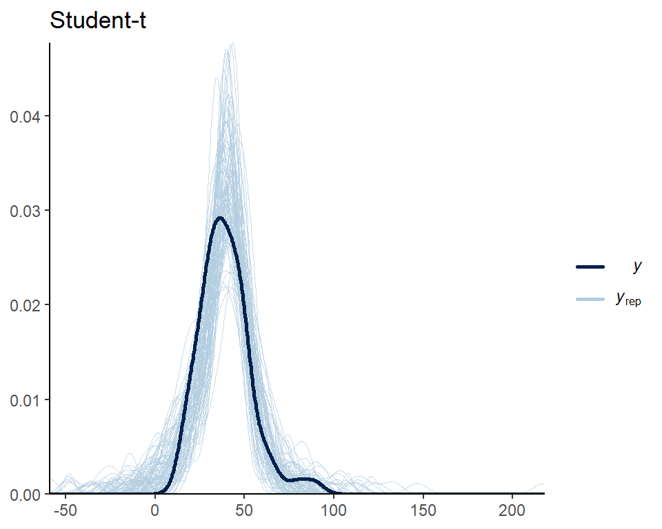

Figure 11: Model diagnostics for student-t distribution with sigma

```r
set.seed(8807)

pp_check(Student_Fit2, ndraws = 100) +
  labs(title = "Student-t") +
  theme_classic()
```

Figure 11 looks good, except for the uncomfortable predictions below 0. For this case, I judge that this does not strongly bias the estimates and their uncertainty. However, this is an aspect I will take into account when doing actual research.

### 3.3.2 Chekcing the results for the student-t distribution with predicted sigma

Now, let’s take a look at the posterior distribution.

```r
describe_posterior(Student_Fit2,
                   centrality = "mean",
                   dispersion = TRUE,
                   ci_method = "HDI",
                   test = "rope",
                   )
```

```
Summary of Posterior Distribution

Parameter             |  Mean |   SD |          95% CI |          ROPE | % in ROPE |  Rhat |     ESS
----------------------------------------------------------------------------------------------------
(Intercept)           | 35.26 | 5.57 | [ 24.38, 46.18] | [-1.42, 1.42] |        0% | 1.002 | 1213.00
sigma_Intercept       |  2.99 | 0.25 | [  2.50,  3.50] | [-1.42, 1.42] |        0% | 1.003 | 1282.00
Day2                  |  5.76 | 6.07 | [ -5.67, 18.18] | [-1.42, 1.42] |    12.24% | 1.002 | 1230.00
GenotypeKO            |  2.27 | 6.86 | [-11.26, 15.75] | [-1.42, 1.42] |    17.18% | 1.003 | 1338.00
Day2:GenotypeKO       | -2.02 | 7.61 | [-16.58, 13.15] | [-1.42, 1.42] |    14.84% | 1.002 | 1314.00
sigma_Day2            | -0.97 | 0.31 | [ -1.57, -0.34] | [-1.42, 1.42] |    95.53% | 1.001 | 1484.00
sigma_GenotypeKO      | -0.33 | 0.31 | [ -0.93,  0.32] | [-1.42, 1.42] |      100% | 1.001 | 1423.00
sigma_Day2:GenotypeKO |  0.30 | 0.44 | [ -0.58,  1.13] | [-1.42, 1.42] |      100% | 1.001 | 1406.00
```

We see more parameters compared to the other two fitted models because the response for sigma is now included as a main effect in the model. Under this scheme, we see that the intercepts are closer to those of the Gaussian model and the effect of genotype (`GenotypeKO`) is reduced by half.

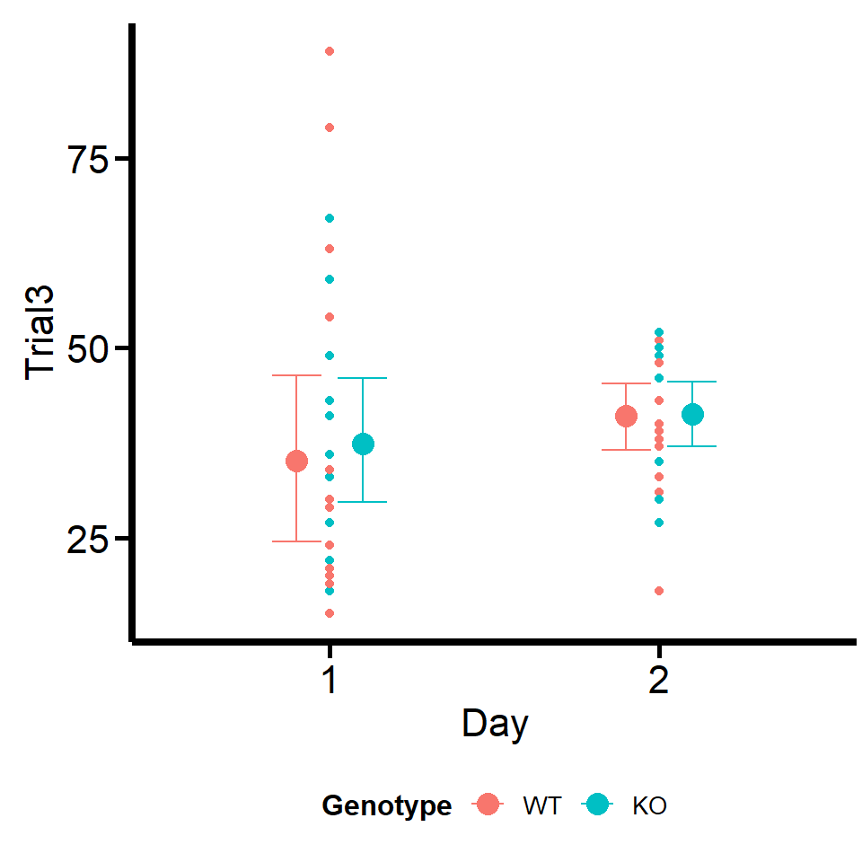

Figure 12: Conditional effects for the Student-t model with sigma

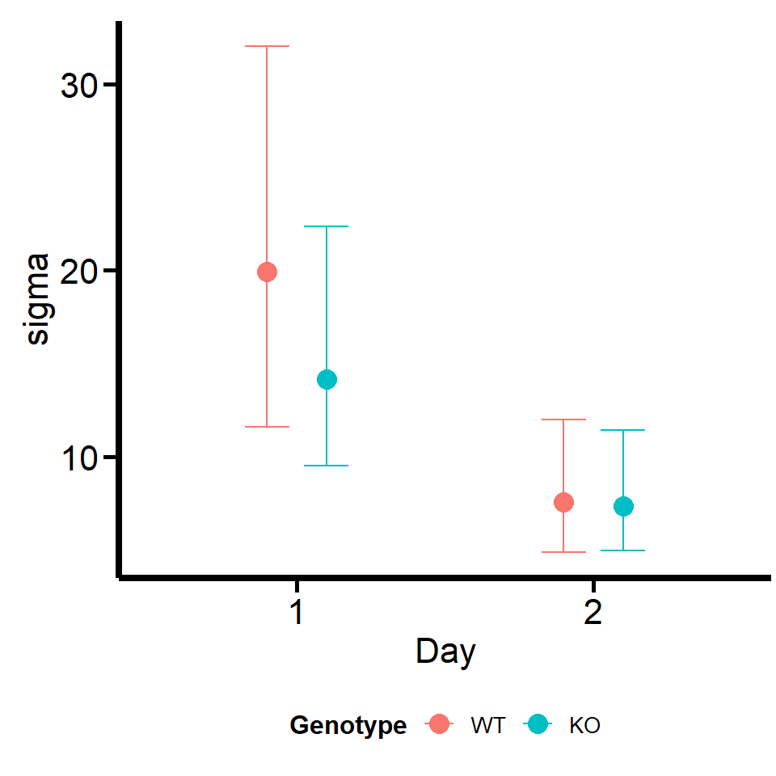

Figure 13: Conditional effects for the Student-t model with sigma

```r
Student_CondEffects2 <-
  conditional_effects(Student_Fit2)

Student_CondEffects2 <- plot(Student_CondEffects2,
       plot = FALSE)[[3]]

Student_CondEffects2 +
  geom_point(data=data, aes(x = Day, y = Trial3, color = Genotype), inherit.aes=FALSE) +
  Plot_theme +
  theme(legend.position = "bottom", legend.direction = "horizontal")


Student_CondEffects3 <-
  conditional_effects(Student_Fit2, dpar = "sigma")

Student_CondEffects3 <- plot(Student_CondEffects3,
       plot = FALSE)[[3]]

Student_CondEffects3 +
  Plot_theme +
  theme(legend.position = "bottom", legend.direction = "horizontal")
```

We can conclude this article by comparing the three models for out-of-sample predictions.

## 3.4 Model comparison

We perform model comparison using the WAIC criteria (*6*)for estimating the out-of-sample prediction error. By considering both the log-likelihood of the observed data and the effective number of parameters, it provides a balance between model fit and complexity. Unlike some other criteria, WAIC inherently accounts for the posterior distribution of the parameters rather than relying on point estimates, making it particularly suited to Bayesian analyses.

Given a data set and a Bayesian model, the WAIC is calculated as:

$$\text{WAIC} = -2 \times \left( \text{LLPD} - p_{\text{WAIC}} \right)$$

Where: $\text{LLPD}$ is the log pointwise predictive density, calculated as the average log likelihood for each observed data point across the posterior samples. $\text{WAIC}$ is the effective number of parameters, computed as the difference between the average of the log likelihoods and the log likelihood of the averages across posterior samples.

We use the `compare_performance` function from the `performance` package, part of the `easystats` environment (*4*, *7*, *8*).

```r
Fit_Comp <-
  compare_performance(
    Gaussian_Fit1,
    Student_Fit,
    Student_Fit2,
    metrics = "all")

Fit_Comp
```

[output not shown]

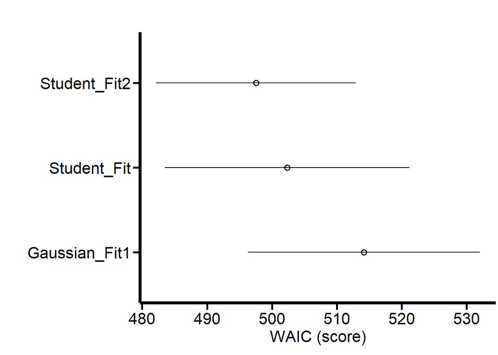

Figure 14: Model camparison by WAIC

```r
Fit_Comp_W <-
loo_compare(
 Gaussian_Fit1,
    Student_Fit,
    Student_Fit2,
  criterion = "waic")

# Generate WAIC graph
Fit_Comp_WAIC <-
  Fit_Comp_W[, 7:8] %>%
  data.frame() %>%
  rownames_to_column(var = "model_name") %>%

ggplot(
  aes(x    = model_name,
      y    = waic,
      ymin = waic - se_waic,
      ymax = waic + se_waic)
  ) +
  geom_pointrange(shape = 21) +
  scale_x_discrete(
    breaks=c("Gaussian_Fit1",
             "Student_Fit",
             "Student_Fit2"),

    labels=c("Gaussian_Fit1",
             "Student_Fit",
             "Student_Fit2")

    ) +
  coord_flip() +
  labs(x = "",
       y = "WAIC (score)",
       title = "") +
  Plot_theme

Fit_Comp_WAIC
```

The Figure 14 shows that our last model is less penalized for out-of-sample prediction.

You can find an updated version of this post on my GitHub site (https://github.com/daniel-manrique/MediumBlog/blob/main/20240222_OutliersStudent-t.qmd). Let me know if this journey was useful to you, and if you have any constructive comments to add to this exercise.

# 4 References

1.

M. Ahsanullah, B. M. G. Kibria, M. Shakil, *Normal and student´s t distributions and their applications* (Atlantis Press, 2014; http://dx.doi.org/10.2991/978-94-6239-061-4).

2.

P.-C. Bürkner, Brms: An r package for bayesian multilevel models using stan. **80** (2017), doi:10.18637/jss.v080.i01.

3.

K. Yang, J. Tu, T. Chen, [Homoscedasticity: an overlooked critical assumption for linear regression](https://doi.org/10.1136/gpsych-2019-100148). *General Psychiatry*. **32**, e100148 (2019).

4.

D. Makowski, M. S. Ben-Shachar, D. Lüdecke, [bayestestR: Describing effects and their uncertainty, existence and significance within the bayesian framework.](https://doi.org/10.21105/joss.01541) **4**, 1541 (2019).

5.

A. Heiss, A guide to modeling proportions with bayesian beta and zero-inflated beta regression models (2021), (available at http://dx.doi.org/10.59350/7p1a4-0tw75).

6.

A. Gelman, J. Hwang, A. Vehtari, [Understanding predictive information criteria for Bayesian models](https://doi.org/10.1007/s11222-013-9416-2). *Statistics and Computing*. **24**, 997–1016 (2013).

7.

D. Lüdecke, M. S. Ben-Shachar, I. Patil, P. Waggoner, D. Makowski, [Performance: An r package for assessment, comparison and testing of statistical models](https://doi.org/10.21105/joss.03139). **6**, 3139 (2021).

8.

D. Makowski, M. Ben-Shachar, D. Lüdecke, [bayestestR: Describing effects and their uncertainty, existence and significance within the bayesian framework](https://doi.org/10.21105/joss.01541). *Journal of Open Source Software*. **4**, 1541 (2019).